# tkorimi_ASSIGNMENT2

```python
!mkdir -p ~/.kaggle
```

```python
from google.colab import files
files.upload()
```

Upload widget is only available when the cell has been executed in the current browser session. Please rerun this cell to enable.

```
Saving kaggle.json to kaggle.json
```

```
{'kaggle.json': b'{"username":"tarunkumarkorimi","key":"73169c2fe4d4266b6145222efdb63bee"}'}
```

```python
!cp kaggle.json ~/.kaggle/
```

```python
!chmod 600 ~/.kaggle/kaggle.json
```

```python
!ls ~/.kaggle
```

```
kaggle.json
```

```python
!kaggle competitions download -c dogs-vs-cats
```

```
Downloading dogs-vs-cats.zip to /content
 99% 804M/812M [00:06<00:00, 225MB/s]
100% 812M/812M [00:06<00:00, 131MB/s]
```

```python
!unzip -qq dogs-vs-cats.zip
```

```python
!unzip -qq train.zip
```

```python
!ls train
```

[output not shown]

[output cut: 3517 more lines]

[output not shown]

Question 1: Consider the Cats & Dogs example. Start initially with a training sample of 1000, a validation sample of 500, and a test sample of 500 (like in the text). Use any technique to reduce overfitting and improve performance in developing a network that you train from scratch. What performance did you achieve?

copying images to the test, validation, and training directories

```python
import os, shutil, pathlib

original_dataset_dir = pathlib.Path("train")
base_dataset_dir = pathlib.Path("cats_vs_dogs_small")

def make_subset(subset_name, start_index, end_index):
    for category in ("cat", "dog"):
        dir = base_dataset_dir / subset_name / category
        os.makedirs(dir, exist_ok=True)
        fnames = [f"{category}.{i}.jpg" for i in range(start_index, end_index)]
        for fname in fnames:
            shutil.copyfile(src=original_dataset_dir / fname,
                            dst=dir / fname)


make_subset("train", start_index=667, end_index=1667)
make_subset("validation", start_index=1668, end_index=2168)
make_subset("test", start_index=2169, end_index=2669)
```

Interpreting images with "image_dataset_from_directory"

```python
from tensorflow.keras.utils import image_dataset_from_directory

train = image_dataset_from_directory(
    base_dataset_dir / "train",
    image_size=(180, 180),
    batch_size=32)

validation = image_dataset_from_directory(
    base_dataset_dir / "validation",
    image_size=(180, 180),
    batch_size=32)

test = image_dataset_from_directory(
    base_dataset_dir / "test",
    image_size=(180, 180),
    batch_size=32)
```

```
Found 2000 files belonging to 2 classes.
Found 1000 files belonging to 2 classes.
Found 1000 files belonging to 2 classes.
```

Create a dataset instance with 1000 random samples, each with a vector size of 16 using a NumPy array.

```python
import numpy as np
import tensorflow as tf
random_num = np.random.normal(size=(1000, 16))
data = tf.data.Dataset.from_tensor_slices(random_num)
```

```python
for i, element in enumerate(data):
    print(element.shape)
    if i >= 2:
        break
```

```
(16,)
(16,)
(16,)
```

```python
for i, element in enumerate(data):
    print(element.shape)
    if i >= 2:
        break
```

```
(16,)
(16,)
(16,)
```

```python
reshapedata = data.map(lambda x: tf.reshape(x, (4, 4)))
for i, element in enumerate(reshapedata):
    print(element.shape)
    if i >= 2:
        break
```

```
(4, 4)
(4, 4)
(4, 4)
```

Developing the model

Creating a tiny network for categorizing dogs versus cats

```python
for data_batch, labels_batch in train:
    print("data batch shape:", data_batch.shape)
    print("labels batch shape:", labels_batch.shape)
    break
```

```
data batch shape: (32, 180, 180, 3)
labels batch shape: (32,)
```

```python
from tensorflow import keras
from tensorflow.keras import layers

input = keras.Input(shape=(180, 180, 3))
a = layers.Rescaling(1./255)(input)
a = layers.Conv2D(filters=32, kernel_size=3, activation="relu")(a)
a = layers.MaxPooling2D(pool_size=2)(a)
a = layers.Conv2D(filters=64, kernel_size=3, activation="relu")(a)
a = layers.MaxPooling2D(pool_size=2)(a)
a = layers.Conv2D(filters=128, kernel_size=3, activation="relu")(a)
a = layers.MaxPooling2D(pool_size=2)(a)
a = layers.Conv2D(filters=256, kernel_size=3, activation="relu")(a)
a = layers.MaxPooling2D(pool_size=2)(a)
a = layers.Conv2D(filters=256, kernel_size=3, activation="relu")(a)
a = layers.Flatten()(a)
a = layers.Dropout(0.5)(a)
output1 = layers.Dense(1, activation="sigmoid")(a)
model1 = keras.Model(inputs=input, outputs=output1)
```

preparing model for training

```python
model1.compile(loss="binary_crossentropy",
              optimizer="adam",
              metrics=["accuracy"])
```

The model is constructed at first, then it is then trained using the training dataset. We use the validation dataset to verify the model's performance at the end of each phase. I'm utilizing a GPU to reduce the processing length of each phase.

```python
model1.summary()
```

```
Model: "functional"
```

```
┏━━━━━━━━━━━━━━━━━━━━━━━━━━━━━━━━━━━━━━┳━━━━━━━━━━━━━━━━━━━━━━━━━━━━━┳━━━━━━━━━━━━━━━━━┓
┃ Layer (type)                         ┃ Output Shape                ┃         Param # ┃
┡━━━━━━━━━━━━━━━━━━━━━━━━━━━━━━━━━━━━━━╇━━━━━━━━━━━━━━━━━━━━━━━━━━━━━╇━━━━━━━━━━━━━━━━━┩
│ input_layer (InputLayer)             │ (None, 180, 180, 3)         │               0 │
├──────────────────────────────────────┼─────────────────────────────┼─────────────────┤
│ rescaling (Rescaling)                │ (None, 180, 180, 3)         │               0 │
├──────────────────────────────────────┼─────────────────────────────┼─────────────────┤
│ conv2d (Conv2D)                      │ (None, 178, 178, 32)        │             896 │
├──────────────────────────────────────┼─────────────────────────────┼─────────────────┤
│ max_pooling2d (MaxPooling2D)         │ (None, 89, 89, 32)          │               0 │
├──────────────────────────────────────┼─────────────────────────────┼─────────────────┤
│ conv2d_1 (Conv2D)                    │ (None, 87, 87, 64)          │          18,496 │
├──────────────────────────────────────┼─────────────────────────────┼─────────────────┤
│ max_pooling2d_1 (MaxPooling2D)       │ (None, 43, 43, 64)          │               0 │
├──────────────────────────────────────┼─────────────────────────────┼─────────────────┤
│ conv2d_2 (Conv2D)                    │ (None, 41, 41, 128)         │          73,856 │
├──────────────────────────────────────┼─────────────────────────────┼─────────────────┤
│ max_pooling2d_2 (MaxPooling2D)       │ (None, 20, 20, 128)         │               0 │
├──────────────────────────────────────┼─────────────────────────────┼─────────────────┤
│ conv2d_3 (Conv2D)                    │ (None, 18, 18, 256)         │         295,168 │
├──────────────────────────────────────┼─────────────────────────────┼─────────────────┤
│ max_pooling2d_3 (MaxPooling2D)       │ (None, 9, 9, 256)           │               0 │
├──────────────────────────────────────┼─────────────────────────────┼─────────────────┤
│ conv2d_4 (Conv2D)                    │ (None, 7, 7, 256)           │         590,080 │
├──────────────────────────────────────┼─────────────────────────────┼─────────────────┤
│ flatten (Flatten)                    │ (None, 12544)               │               0 │
├──────────────────────────────────────┼─────────────────────────────┼─────────────────┤
│ dropout (Dropout)                    │ (None, 12544)               │               0 │
├──────────────────────────────────────┼─────────────────────────────┼─────────────────┤
│ dense (Dense)                        │ (None, 1)                   │          12,545 │
└──────────────────────────────────────┴─────────────────────────────┴─────────────────┘
```

```
 Total params: 991,041 (3.78 MB)
```

```
 Trainable params: 991,041 (3.78 MB)
```

```
 Non-trainable params: 0 (0.00 B)
```

Model fitting follows using the dataset.

```python
from keras.callbacks import ModelCheckpoint, EarlyStopping

callback1 = [
    keras.callbacks.ModelCheckpoint(
        filepath="convnet_from_scratch.keras",
        save_best_only=True,
        monitor="val_loss")
]
history1 = model1.fit(
    train,
    epochs=10,
    validation_data=validation,
    callbacks=callback1)
```

```
63/63 ━━━━━━━━━━━━━━━━━━━━ 22s 192ms/step - accuracy: 0.5157 - loss: 0.6956 - val_accuracy: 0.5000 - val_loss: 0.7916
63/63 ━━━━━━━━━━━━━━━━━━━━ 5s 53ms/step - accuracy: 0.5065 - loss: 0.6976 - val_accuracy: 0.5210 - val_loss: 0.6842
63/63 ━━━━━━━━━━━━━━━━━━━━ 5s 85ms/step - accuracy: 0.5519 - loss: 0.6865 - val_accuracy: 0.5080 - val_loss: 0.6856
63/63 ━━━━━━━━━━━━━━━━━━━━ 4s 66ms/step - accuracy: 0.5399 - loss: 0.6886 - val_accuracy: 0.6350 - val_loss: 0.6675
63/63 ━━━━━━━━━━━━━━━━━━━━ 4s 52ms/step - accuracy: 0.6342 - loss: 0.6491 - val_accuracy: 0.6550 - val_loss: 0.6369
63/63 ━━━━━━━━━━━━━━━━━━━━ 3s 54ms/step - accuracy: 0.6735 - loss: 0.6173 - val_accuracy: 0.6020 - val_loss: 0.6854
63/63 ━━━━━━━━━━━━━━━━━━━━ 6s 74ms/step - accuracy: 0.6612 - loss: 0.6070 - val_accuracy: 0.6630 - val_loss: 0.6200
63/63 ━━━━━━━━━━━━━━━━━━━━ 3s 52ms/step - accuracy: 0.6830 - loss: 0.5747 - val_accuracy: 0.6780 - val_loss: 0.6192
63/63 ━━━━━━━━━━━━━━━━━━━━ 3s 51ms/step - accuracy: 0.7219 - loss: 0.5465 - val_accuracy: 0.6880 - val_loss: 0.6204
63/63 ━━━━━━━━━━━━━━━━━━━━ 8s 99ms/step - accuracy: 0.7524 - loss: 0.5031 - val_accuracy: 0.6960 - val_loss: 0.6111
```

In order to improve visualization and understanding, training curves for accuracy and loss were created.

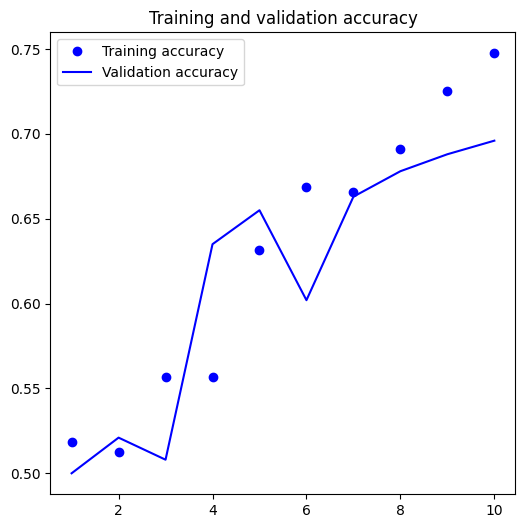

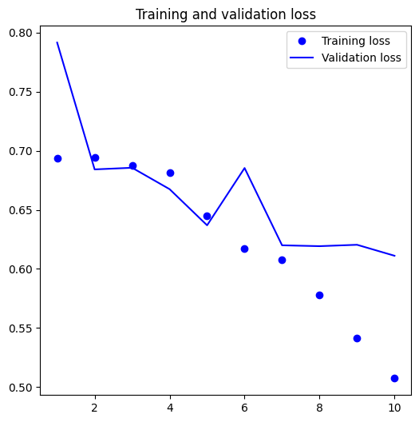

```python
import matplotlib.pyplot as plt

plt.figure(figsize=(6, 6))
accuracy1 = history1.history["accuracy"]
val_accuracy1 = history1.history["val_accuracy"]
loss1 = history1.history["loss"]
val_loss1 = history1.history["val_loss"]
epochs = range(1, len(accuracy1) + 1)
plt.plot(epochs, accuracy1, "bo", label="Training accuracy")
plt.plot(epochs, val_accuracy1, "b", label="Validation accuracy")
plt.title("Training and validation accuracy")
plt.legend()
plt.figure()
plt.figure(figsize=(6, 6))
plt.plot(epochs, loss1, "bo", label="Training loss")
plt.plot(epochs, val_loss1, "b", label="Validation loss")
plt.title("Training and validation loss")
plt.legend()
plt.show()
```

```python
testacc1 = keras.models.load_model("convnet_from_scratch.keras")
test_loss, test_acc = testacc1.evaluate(test)
print(f"Test accuracy: {test_acc:.3f}")
```

```
32/32 ━━━━━━━━━━━━━━━━━━━━ 2s 38ms/step - accuracy: 0.6967 - loss: 0.5816
Test accuracy: 0.685
```

Question 2: Increase your training sample size. You may pick any amount. Keep the validation and test samples the same as above. Optimize your network (again training from scratch). What performance did you achieve?

Using data augmentation

Define a data augmentation stage to add to an image model

```python
import os, shutil, pathlib

shutil.rmtree("./cats_vs_dogs_small_Q2", ignore_errors=True)

# Define the original directory and the new base directory
original_dataset_dir = pathlib.Path("train")
base_dataset_dir = pathlib.Path("cats_vs_dogs_small_Q2")

# Function to create subsets
def make_subset(subset_name, start_index, end_index):
    for category in ("cat", "dog"):
        dir = base_dataset_dir / subset_name / category
        os.makedirs(dir, exist_ok=True)  # Create directory, if it doesn't exist
        fnames = [f"{category}.{i}.jpg" for i in range(start_index, end_index)]
        for fname in fnames:
            shutil.copyfile(src=original_dataset_dir / fname,
                            dst=dir / fname)

# Creating subsets for training, validation, and testing
make_subset("train", start_index=667, end_index=2167)  # 1500 samples
make_subset("validation", start_index=2168, end_index=2668)  # 500 samples
make_subset("test", start_index=2669, end_index=3168)  # 500 samples
```

```python
augmentation = keras.Sequential(
    [
        layers.RandomFlip("horizontal"),
        layers.RandomRotation(0.1),
        layers.RandomZoom(0.2),
    ]
)
```

showing the training augmented pictures

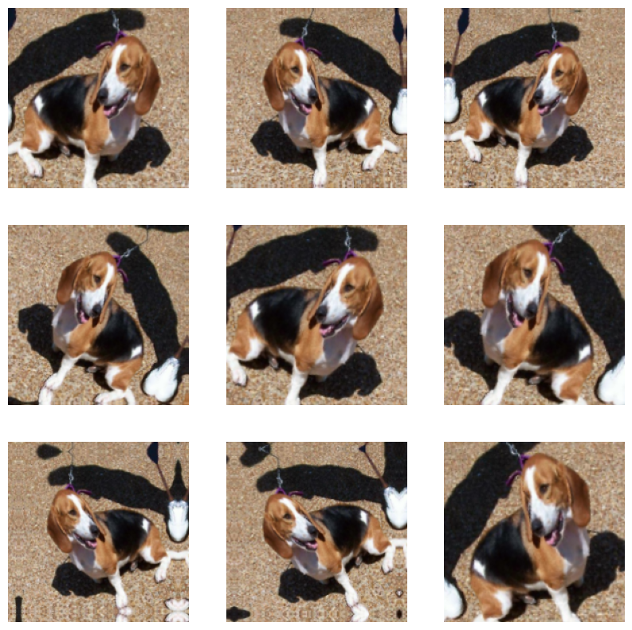

```python
plt.figure(figsize=(10, 10))
for images, _ in train.take(1):
    for i in range(9):
        augmented_pics = augmentation(images)
        ax = plt.subplot(3, 3, i + 1)
        plt.imshow(augmented_pics[0].numpy().astype("uint8"))
        plt.axis("off")
```

Developing a new convolutional neural network that includes picture augmentation and dropout

```python
input2 = keras.Input(shape=(180, 180, 3))
b = augmentation(input2)
b = layers.Rescaling(1./255)(b)
b = layers.Conv2D(filters=32, kernel_size=3, activation="relu")(b)
b = layers.MaxPooling2D(pool_size=2)(b)
b = layers.Conv2D(filters=64, kernel_size=3, activation="relu")(b)
b = layers.MaxPooling2D(pool_size=2)(b)
b = layers.Conv2D(filters=128, kernel_size=3, activation="relu")(b)
b = layers.MaxPooling2D(pool_size=2)(b)
b = layers.Conv2D(filters=256, kernel_size=3, activation="relu")(b)
b = layers.MaxPooling2D(pool_size=2)(b)
b = layers.Conv2D(filters=256, kernel_size=3, activation="relu")(b)
b = layers.Flatten()(b)
b = layers.Dropout(0.5)(b)
output2 = layers.Dense(1, activation="sigmoid")(b)
model2 = keras.Model(inputs=input2, outputs=output2)

model2.compile(loss="binary_crossentropy",
              optimizer="adam",
              metrics=["accuracy"])
```

```python
from keras.callbacks import ModelCheckpoint, EarlyStopping
callback2 = [
    keras.callbacks.ModelCheckpoint(
        filepath="convnet_from_scratch_with_augmentation.keras",
        save_best_only=True,
        monitor="val_loss")
]
history2 = model2.fit(
    train,
    epochs=30,
    validation_data=validation,
    callbacks=callback2)
```

```
63/63 ━━━━━━━━━━━━━━━━━━━━ 10s 71ms/step - accuracy: 0.5086 - loss: 0.7039 - val_accuracy: 0.5000 - val_loss: 0.6932
63/63 ━━━━━━━━━━━━━━━━━━━━ 8s 85ms/step - accuracy: 0.5091 - loss: 0.6931 - val_accuracy: 0.5000 - val_loss: 0.6931
63/63 ━━━━━━━━━━━━━━━━━━━━ 4s 62ms/step - accuracy: 0.5137 - loss: 0.6931 - val_accuracy: 0.5850 - val_loss: 0.6930
63/63 ━━━━━━━━━━━━━━━━━━━━ 5s 61ms/step - accuracy: 0.4659 - loss: 0.6934 - val_accuracy: 0.5000 - val_loss: 0.6931
63/63 ━━━━━━━━━━━━━━━━━━━━ 6s 93ms/step - accuracy: 0.4992 - loss: 0.6932 - val_accuracy: 0.5020 - val_loss: 0.6919
63/63 ━━━━━━━━━━━━━━━━━━━━ 8s 54ms/step - accuracy: 0.4911 - loss: 0.6944 - val_accuracy: 0.5070 - val_loss: 0.6930
63/63 ━━━━━━━━━━━━━━━━━━━━ 5s 84ms/step - accuracy: 0.5000 - loss: 0.6952 - val_accuracy: 0.5000 - val_loss: 0.6932
63/63 ━━━━━━━━━━━━━━━━━━━━ 8s 54ms/step - accuracy: 0.4751 - loss: 0.6940 - val_accuracy: 0.5000 - val_loss: 0.6931
63/63 ━━━━━━━━━━━━━━━━━━━━ 5s 81ms/step - accuracy: 0.5186 - loss: 0.6931 - val_accuracy: 0.5000 - val_loss: 0.6930
63/63 ━━━━━━━━━━━━━━━━━━━━ 5s 75ms/step - accuracy: 0.5265 - loss: 0.6924 - val_accuracy: 0.5080 - val_loss: 0.6930
63/63 ━━━━━━━━━━━━━━━━━━━━ 3s 55ms/step - accuracy: 0.4855 - loss: 0.6937 - val_accuracy: 0.5220 - val_loss: 0.6879
63/63 ━━━━━━━━━━━━━━━━━━━━ 6s 66ms/step - accuracy: 0.5354 - loss: 0.6858 - val_accuracy: 0.5580 - val_loss: 0.6846
63/63 ━━━━━━━━━━━━━━━━━━━━ 5s 87ms/step - accuracy: 0.5550 - loss: 0.6854 - val_accuracy: 0.5140 - val_loss: 0.6910
63/63 ━━━━━━━━━━━━━━━━━━━━ 3s 53ms/step - accuracy: 0.5044 - loss: 0.6894 - val_accuracy: 0.5010 - val_loss: 0.6937
63/63 ━━━━━━━━━━━━━━━━━━━━ 3s 54ms/step - accuracy: 0.5189 - loss: 0.6939 - val_accuracy: 0.5000 - val_loss: 0.6933
63/63 ━━━━━━━━━━━━━━━━━━━━ 4s 65ms/step - accuracy: 0.4874 - loss: 0.6938 - val_accuracy: 0.5480 - val_loss: 0.6886
63/63 ━━━━━━━━━━━━━━━━━━━━ 5s 67ms/step - accuracy: 0.5370 - loss: 0.6862 - val_accuracy: 0.5300 - val_loss: 0.6867
63/63 ━━━━━━━━━━━━━━━━━━━━ 3s 54ms/step - accuracy: 0.5559 - loss: 0.6860 - val_accuracy: 0.5350 - val_loss: 0.6855
63/63 ━━━━━━━━━━━━━━━━━━━━ 7s 82ms/step - accuracy: 0.5664 - loss: 0.6864 - val_accuracy: 0.5320 - val_loss: 0.6862
63/63 ━━━━━━━━━━━━━━━━━━━━ 5s 71ms/step - accuracy: 0.5665 - loss: 0.6800 - val_accuracy: 0.5730 - val_loss: 0.6773
63/63 ━━━━━━━━━━━━━━━━━━━━ 4s 60ms/step - accuracy: 0.5831 - loss: 0.6809 - val_accuracy: 0.5010 - val_loss: 0.6965
63/63 ━━━━━━━━━━━━━━━━━━━━ 5s 66ms/step - accuracy: 0.5128 - loss: 0.6901 - val_accuracy: 0.5640 - val_loss: 0.6682
63/63 ━━━━━━━━━━━━━━━━━━━━ 6s 76ms/step - accuracy: 0.6137 - loss: 0.6637 - val_accuracy: 0.6380 - val_loss: 0.6436
63/63 ━━━━━━━━━━━━━━━━━━━━ 4s 61ms/step - accuracy: 0.6475 - loss: 0.6302 - val_accuracy: 0.5950 - val_loss: 0.6573
63/63 ━━━━━━━━━━━━━━━━━━━━ 7s 83ms/step - accuracy: 0.6370 - loss: 0.6427 - val_accuracy: 0.6280 - val_loss: 0.6514
63/63 ━━━━━━━━━━━━━━━━━━━━ 9s 56ms/step - accuracy: 0.6459 - loss: 0.6317 - val_accuracy: 0.6410 - val_loss: 0.6371
63/63 ━━━━━━━━━━━━━━━━━━━━ 5s 84ms/step - accuracy: 0.6710 - loss: 0.6090 - val_accuracy: 0.6870 - val_loss: 0.6129
63/63 ━━━━━━━━━━━━━━━━━━━━ 5s 73ms/step - accuracy: 0.6640 - loss: 0.6261 - val_accuracy: 0.6030 - val_loss: 0.7129
63/63 ━━━━━━━━━━━━━━━━━━━━ 4s 55ms/step - accuracy: 0.6841 - loss: 0.6004 - val_accuracy: 0.6400 - val_loss: 0.6628
63/63 ━━━━━━━━━━━━━━━━━━━━ 7s 87ms/step - accuracy: 0.6710 - loss: 0.6029 - val_accuracy: 0.6370 - val_loss: 0.6772
```

Model evaluated based on test set

```python
testacc2 = keras.models.load_model(
    "convnet_from_scratch_with_augmentation.keras")
test_loss, test_acc = testacc2.evaluate(test)
print(f"Test accuracy: {test_acc:.3f}")
```

```
32/32 ━━━━━━━━━━━━━━━━━━━━ 1s 29ms/step - accuracy: 0.6929 - loss: 0.5904
Test accuracy: 0.684
```

Question 3: Now change your training sample so that you achieve better performance than those from Steps 1 and 2. This sample size may be larger, or smaller than those in the previous steps. The objective is to find the ideal training sample size to get best prediction results.

```python
original_dir = pathlib.Path("train")
new_base_dir = pathlib.Path("cats_vs_dogs_small_Q3")

def make_subset(subset_name, start_index, end_index):
    for category in ("cat", "dog"):
        dir = new_base_dir / subset_name / category
        os.makedirs(dir)
        fnames = [f"{category}.{i}.jpg" for i in range(start_index, end_index)]
        for fname in fnames:
            shutil.copyfile(src=original_dir / fname,
                            dst=dir / fname)
#Creating training, Test and validation sets.
#Training has 2000 samples, test has 500 samples and validation has 500 samples.
make_subset("train", start_index=667, end_index=2667)
make_subset("validation", start_index=2668, end_index=3168)
make_subset("test", start_index=3169, end_index=3669)
```

```python
i3 = keras.Input(shape=(180, 180, 3))
c = augmentation(i3)
c = layers.Rescaling(1./255)(c)
c = layers.Conv2D(filters=32, kernel_size=3, activation="relu")(c)
c = layers.MaxPooling2D(pool_size=2)(c)
c = layers.Conv2D(filters=64, kernel_size=3, activation="relu")(c)
c = layers.MaxPooling2D(pool_size=2)(c)
c = layers.Conv2D(filters=128, kernel_size=3, activation="relu")(c)
c = layers.MaxPooling2D(pool_size=2)(c)
c = layers.Conv2D(filters=256, kernel_size=3, activation="relu")(c)
c = layers.MaxPooling2D(pool_size=2)(c)
c = layers.Conv2D(filters=256, kernel_size=3, activation="relu")(c)
c = layers.Flatten()(c)
c = layers.Dropout(0.5)(c)
out3 = layers.Dense(1, activation="sigmoid")(c)
mod3 = keras.Model(inputs=i3, outputs=out3)

mod3.compile(loss="binary_crossentropy",
              optimizer="adam",
              metrics=["accuracy"])
```

```python
callback3 = [
    keras.callbacks.ModelCheckpoint(
        filepath="convnet_from_scratch_with_augmentation1.keras",
        save_best_only=True,
        monitor="val_loss")
]
hist3 = mod3.fit(
    train,
    epochs=50,
    validation_data=validation,
    callbacks=callback3)
```

```
63/63 ━━━━━━━━━━━━━━━━━━━━ 8s 96ms/step - accuracy: 0.4938 - loss: 0.7073 - val_accuracy: 0.5090 - val_loss: 0.6931
63/63 ━━━━━━━━━━━━━━━━━━━━ 8s 63ms/step - accuracy: 0.5191 - loss: 0.6931 - val_accuracy: 0.6240 - val_loss: 0.6911
63/63 ━━━━━━━━━━━━━━━━━━━━ 4s 67ms/step - accuracy: 0.5437 - loss: 0.6905 - val_accuracy: 0.5060 - val_loss: 0.6867
63/63 ━━━━━━━━━━━━━━━━━━━━ 5s 69ms/step - accuracy: 0.5134 - loss: 0.6923 - val_accuracy: 0.5270 - val_loss: 0.6904
63/63 ━━━━━━━━━━━━━━━━━━━━ 4s 55ms/step - accuracy: 0.5013 - loss: 0.6885 - val_accuracy: 0.5270 - val_loss: 0.6881
63/63 ━━━━━━━━━━━━━━━━━━━━ 3s 55ms/step - accuracy: 0.5239 - loss: 0.6914 - val_accuracy: 0.5160 - val_loss: 0.6979
63/63 ━━━━━━━━━━━━━━━━━━━━ 6s 74ms/step - accuracy: 0.5199 - loss: 0.6911 - val_accuracy: 0.5370 - val_loss: 0.6856
63/63 ━━━━━━━━━━━━━━━━━━━━ 4s 55ms/step - accuracy: 0.5541 - loss: 0.6840 - val_accuracy: 0.6300 - val_loss: 0.6532
63/63 ━━━━━━━━━━━━━━━━━━━━ 4s 62ms/step - accuracy: 0.6070 - loss: 0.6537 - val_accuracy: 0.6450 - val_loss: 0.6369
63/63 ━━━━━━━━━━━━━━━━━━━━ 7s 85ms/step - accuracy: 0.5917 - loss: 0.6706 - val_accuracy: 0.6330 - val_loss: 0.6551
63/63 ━━━━━━━━━━━━━━━━━━━━ 4s 61ms/step - accuracy: 0.6283 - loss: 0.6458 - val_accuracy: 0.5740 - val_loss: 0.6820
63/63 ━━━━━━━━━━━━━━━━━━━━ 3s 55ms/step - accuracy: 0.6395 - loss: 0.6432 - val_accuracy: 0.6360 - val_loss: 0.6433
63/63 ━━━━━━━━━━━━━━━━━━━━ 8s 103ms/step - accuracy: 0.6471 - loss: 0.6310 - val_accuracy: 0.6370 - val_loss: 0.6613
63/63 ━━━━━━━━━━━━━━━━━━━━ 7s 56ms/step - accuracy: 0.6659 - loss: 0.6197 - val_accuracy: 0.6790 - val_loss: 0.6187
63/63 ━━━━━━━━━━━━━━━━━━━━ 7s 80ms/step - accuracy: 0.6608 - loss: 0.6301 - val_accuracy: 0.6780 - val_loss: 0.6219
63/63 ━━━━━━━━━━━━━━━━━━━━ 4s 68ms/step - accuracy: 0.6825 - loss: 0.6074 - val_accuracy: 0.6570 - val_loss: 0.6124
63/63 ━━━━━━━━━━━━━━━━━━━━ 4s 56ms/step - accuracy: 0.6783 - loss: 0.6075 - val_accuracy: 0.7250 - val_loss: 0.5735
63/63 ━━━━━━━━━━━━━━━━━━━━ 4s 61ms/step - accuracy: 0.6830 - loss: 0.6000 - val_accuracy: 0.6830 - val_loss: 0.5897
63/63 ━━━━━━━━━━━━━━━━━━━━ 6s 88ms/step - accuracy: 0.6831 - loss: 0.5989 - val_accuracy: 0.7150 - val_loss: 0.5609
63/63 ━━━━━━━━━━━━━━━━━━━━ 4s 63ms/step - accuracy: 0.7152 - loss: 0.5669 - val_accuracy: 0.7310 - val_loss: 0.5458
63/63 ━━━━━━━━━━━━━━━━━━━━ 5s 61ms/step - accuracy: 0.7316 - loss: 0.5491 - val_accuracy: 0.7290 - val_loss: 0.5498
63/63 ━━━━━━━━━━━━━━━━━━━━ 6s 98ms/step - accuracy: 0.7378 - loss: 0.5459 - val_accuracy: 0.6510 - val_loss: 0.6209
63/63 ━━━━━━━━━━━━━━━━━━━━ 4s 57ms/step - accuracy: 0.7315 - loss: 0.5381 - val_accuracy: 0.7440 - val_loss: 0.5114
63/63 ━━━━━━━━━━━━━━━━━━━━ 3s 55ms/step - accuracy: 0.7324 - loss: 0.5259 - val_accuracy: 0.7120 - val_loss: 0.5972
63/63 ━━━━━━━━━━━━━━━━━━━━ 4s 62ms/step - accuracy: 0.7492 - loss: 0.5079 - val_accuracy: 0.7510 - val_loss: 0.5011
63/63 ━━━━━━━━━━━━━━━━━━━━ 6s 71ms/step - accuracy: 0.7609 - loss: 0.5132 - val_accuracy: 0.6930 - val_loss: 0.6117
63/63 ━━━━━━━━━━━━━━━━━━━━ 4s 56ms/step - accuracy: 0.7566 - loss: 0.4975 - val_accuracy: 0.7640 - val_loss: 0.4752
63/63 ━━━━━━━━━━━━━━━━━━━━ 4s 61ms/step - accuracy: 0.7652 - loss: 0.4891 - val_accuracy: 0.7550 - val_loss: 0.5073
63/63 ━━━━━━━━━━━━━━━━━━━━ 7s 86ms/step - accuracy: 0.7898 - loss: 0.4658 - val_accuracy: 0.7770 - val_loss: 0.4718
63/63 ━━━━━━━━━━━━━━━━━━━━ 9s 61ms/step - accuracy: 0.7915 - loss: 0.4592 - val_accuracy: 0.6870 - val_loss: 0.7037
63/63 ━━━━━━━━━━━━━━━━━━━━ 7s 87ms/step - accuracy: 0.7721 - loss: 0.4790 - val_accuracy: 0.7870 - val_loss: 0.4716
63/63 ━━━━━━━━━━━━━━━━━━━━ 8s 55ms/step - accuracy: 0.7882 - loss: 0.4321 - val_accuracy: 0.7710 - val_loss: 0.4903
63/63 ━━━━━━━━━━━━━━━━━━━━ 9s 111ms/step - accuracy: 0.7900 - loss: 0.4503 - val_accuracy: 0.8020 - val_loss: 0.4528
63/63 ━━━━━━━━━━━━━━━━━━━━ 7s 55ms/step - accuracy: 0.8026 - loss: 0.4253 - val_accuracy: 0.7550 - val_loss: 0.5129
63/63 ━━━━━━━━━━━━━━━━━━━━ 6s 88ms/step - accuracy: 0.8108 - loss: 0.4189 - val_accuracy: 0.8060 - val_loss: 0.4630
63/63 ━━━━━━━━━━━━━━━━━━━━ 8s 56ms/step - accuracy: 0.8078 - loss: 0.4076 - val_accuracy: 0.7940 - val_loss: 0.4573
63/63 ━━━━━━━━━━━━━━━━━━━━ 8s 95ms/step - accuracy: 0.8198 - loss: 0.3999 - val_accuracy: 0.7650 - val_loss: 0.5137
63/63 ━━━━━━━━━━━━━━━━━━━━ 4s 57ms/step - accuracy: 0.8096 - loss: 0.4074 - val_accuracy: 0.7740 - val_loss: 0.5006
63/63 ━━━━━━━━━━━━━━━━━━━━ 5s 55ms/step - accuracy: 0.8197 - loss: 0.3848 - val_accuracy: 0.7750 - val_loss: 0.5096
63/63 ━━━━━━━━━━━━━━━━━━━━ 7s 85ms/step - accuracy: 0.8185 - loss: 0.4106 - val_accuracy: 0.8000 - val_loss: 0.4725
63/63 ━━━━━━━━━━━━━━━━━━━━ 9s 62ms/step - accuracy: 0.8359 - loss: 0.3728 - val_accuracy: 0.7970 - val_loss: 0.4713
63/63 ━━━━━━━━━━━━━━━━━━━━ 6s 81ms/step - accuracy: 0.8419 - loss: 0.3774 - val_accuracy: 0.7940 - val_loss: 0.4776
63/63 ━━━━━━━━━━━━━━━━━━━━ 4s 70ms/step - accuracy: 0.8369 - loss: 0.3775 - val_accuracy: 0.7850 - val_loss: 0.4998
63/63 ━━━━━━━━━━━━━━━━━━━━ 4s 53ms/step - accuracy: 0.8343 - loss: 0.3679 - val_accuracy: 0.7820 - val_loss: 0.4750
63/63 ━━━━━━━━━━━━━━━━━━━━ 7s 91ms/step - accuracy: 0.8469 - loss: 0.3486 - val_accuracy: 0.7680 - val_loss: 0.5072
63/63 ━━━━━━━━━━━━━━━━━━━━ 8s 61ms/step - accuracy: 0.8434 - loss: 0.3724 - val_accuracy: 0.7920 - val_loss: 0.4925
63/63 ━━━━━━━━━━━━━━━━━━━━ 4s 67ms/step - accuracy: 0.8479 - loss: 0.3405 - val_accuracy: 0.8010 - val_loss: 0.4456
63/63 ━━━━━━━━━━━━━━━━━━━━ 5s 68ms/step - accuracy: 0.8636 - loss: 0.3138 - val_accuracy: 0.7210 - val_loss: 0.8223
63/63 ━━━━━━━━━━━━━━━━━━━━ 4s 54ms/step - accuracy: 0.8453 - loss: 0.3500 - val_accuracy: 0.8010 - val_loss: 0.4692
63/63 ━━━━━━━━━━━━━━━━━━━━ 3s 54ms/step - accuracy: 0.8634 - loss: 0.3191 - val_accuracy: 0.7950 - val_loss: 0.5182
```

```python
acc_test3 = keras.models.load_model(
    "convnet_from_scratch_with_augmentation1.keras")
test_loss, test_acc = acc_test3.evaluate(test)
print(f"Test accuracy: {test_acc:.3f}")
```

```
32/32 ━━━━━━━━━━━━━━━━━━━━ 2s 49ms/step - accuracy: 0.8024 - loss: 0.4282
Test accuracy: 0.807
```

Question 4: Repeat Steps 1-3, but now using a pretrained network. The sample sizes you use in Steps 2 and 3 for the pretrained network may be the same or different from those using the network where you trained from scratch. Again, use any and all optimization techniques to get best performance.

Instantiating the VGG16 convolutional base

```python
convolution_base = keras.applications.vgg16.VGG16(
    weights="imagenet",
    include_top=False,
    input_shape=(180, 180, 3))
```

```
Downloading data from https://storage.googleapis.com/tensorflow/keras-applications/vgg16/vgg16_weights_tf_dim_ordering_tf_kernels_notop.h5
58889256/58889256 ━━━━━━━━━━━━━━━━━━━━ 0s 0us/step
```

```python
convolution_base.summary()
```

```
Model: "vgg16"
```

```
┏━━━━━━━━━━━━━━━━━━━━━━━━━━━━━━━━━━━━━━┳━━━━━━━━━━━━━━━━━━━━━━━━━━━━━┳━━━━━━━━━━━━━━━━━┓
┃ Layer (type)                         ┃ Output Shape                ┃         Param # ┃
┡━━━━━━━━━━━━━━━━━━━━━━━━━━━━━━━━━━━━━━╇━━━━━━━━━━━━━━━━━━━━━━━━━━━━━╇━━━━━━━━━━━━━━━━━┩
│ input_layer_4 (InputLayer)           │ (None, 180, 180, 3)         │               0 │
├──────────────────────────────────────┼─────────────────────────────┼─────────────────┤
│ block1_conv1 (Conv2D)                │ (None, 180, 180, 64)        │           1,792 │
├──────────────────────────────────────┼─────────────────────────────┼─────────────────┤
│ block1_conv2 (Conv2D)                │ (None, 180, 180, 64)        │          36,928 │
├──────────────────────────────────────┼─────────────────────────────┼─────────────────┤
│ block1_pool (MaxPooling2D)           │ (None, 90, 90, 64)          │               0 │
├──────────────────────────────────────┼─────────────────────────────┼─────────────────┤
│ block2_conv1 (Conv2D)                │ (None, 90, 90, 128)         │          73,856 │
├──────────────────────────────────────┼─────────────────────────────┼─────────────────┤
│ block2_conv2 (Conv2D)                │ (None, 90, 90, 128)         │         147,584 │
├──────────────────────────────────────┼─────────────────────────────┼─────────────────┤
│ block2_pool (MaxPooling2D)           │ (None, 45, 45, 128)         │               0 │
├──────────────────────────────────────┼─────────────────────────────┼─────────────────┤
│ block3_conv1 (Conv2D)                │ (None, 45, 45, 256)         │         295,168 │
├──────────────────────────────────────┼─────────────────────────────┼─────────────────┤
│ block3_conv2 (Conv2D)                │ (None, 45, 45, 256)         │         590,080 │
├──────────────────────────────────────┼─────────────────────────────┼─────────────────┤
│ block3_conv3 (Conv2D)                │ (None, 45, 45, 256)         │         590,080 │
├──────────────────────────────────────┼─────────────────────────────┼─────────────────┤
│ block3_pool (MaxPooling2D)           │ (None, 22, 22, 256)         │               0 │
├──────────────────────────────────────┼─────────────────────────────┼─────────────────┤
│ block4_conv1 (Conv2D)                │ (None, 22, 22, 512)         │       1,180,160 │
├──────────────────────────────────────┼─────────────────────────────┼─────────────────┤
│ block4_conv2 (Conv2D)                │ (None, 22, 22, 512)         │       2,359,808 │
├──────────────────────────────────────┼─────────────────────────────┼─────────────────┤
│ block4_conv3 (Conv2D)                │ (None, 22, 22, 512)         │       2,359,808 │
├──────────────────────────────────────┼─────────────────────────────┼─────────────────┤
│ block4_pool (MaxPooling2D)           │ (None, 11, 11, 512)         │               0 │
├──────────────────────────────────────┼─────────────────────────────┼─────────────────┤
│ block5_conv1 (Conv2D)                │ (None, 11, 11, 512)         │       2,359,808 │
├──────────────────────────────────────┼─────────────────────────────┼─────────────────┤
│ block5_conv2 (Conv2D)                │ (None, 11, 11, 512)         │       2,359,808 │
├──────────────────────────────────────┼─────────────────────────────┼─────────────────┤
│ block5_conv3 (Conv2D)                │ (None, 11, 11, 512)         │       2,359,808 │
├──────────────────────────────────────┼─────────────────────────────┼─────────────────┤
│ block5_pool (MaxPooling2D)           │ (None, 5, 5, 512)           │               0 │
└──────────────────────────────────────┴─────────────────────────────┴─────────────────┘
```

```
 Total params: 14,714,688 (56.13 MB)
```

```
 Trainable params: 14,714,688 (56.13 MB)
```

```
 Non-trainable params: 0 (0.00 B)
```

using a pretrained model for feature extraction without data augmentation

obtaining the labels that correlate with the VGG16 characteristics

```python
import numpy as np

def get_features_and_labels(dataset):
    all_feature = []
    all_label = []
    for images, labels in dataset:
        preprocessed_images = keras.applications.vgg16.preprocess_input(images)
        features = convolution_base.predict(preprocessed_images)
        all_feature.append(features)
        all_label.append(labels)
    return np.concatenate(all_feature), np.concatenate(all_label)

train_features, train_labels =  get_features_and_labels(train)
val_features, val_labels =  get_features_and_labels(validation)
test_features, test_labels =  get_features_and_labels(test)
```

[output not shown]

[output cut: 72 more lines]

[output not shown]

```python
train_features.shape
```

```
(2000, 5, 5, 512)
```

```python
i6 = keras.Input(shape=(5, 5, 512))
d = layers.Flatten()(i6)
d = layers.Dense(256)(d)
d = layers.Dropout(0.5)(d)
out6 = layers.Dense(1, activation="sigmoid")(d)
m6 = keras.Model(i6, out6)
m6.compile(loss="binary_crossentropy",
              optimizer="rmsprop",
              metrics=["accuracy"])

callback6 = [
    keras.callbacks.ModelCheckpoint(
      filepath="feature_extraction.keras",
      save_best_only=True,
      monitor="val_loss")
]
hist6 = m6.fit(
    train_features, train_labels,
    epochs=20,
    validation_data=(val_features, val_labels),
    callbacks=callback6)
```

```
63/63 ━━━━━━━━━━━━━━━━━━━━ 4s 34ms/step - accuracy: 0.8587 - loss: 41.3700 - val_accuracy: 0.9680 - val_loss: 4.6385
63/63 ━━━━━━━━━━━━━━━━━━━━ 0s 5ms/step - accuracy: 0.9768 - loss: 3.8655 - val_accuracy: 0.9690 - val_loss: 3.8934
63/63 ━━━━━━━━━━━━━━━━━━━━ 0s 3ms/step - accuracy: 0.9801 - loss: 1.9199 - val_accuracy: 0.9730 - val_loss: 4.1849
63/63 ━━━━━━━━━━━━━━━━━━━━ 0s 5ms/step - accuracy: 0.9885 - loss: 1.3111 - val_accuracy: 0.9770 - val_loss: 3.6821
63/63 ━━━━━━━━━━━━━━━━━━━━ 0s 3ms/step - accuracy: 0.9930 - loss: 0.4904 - val_accuracy: 0.9750 - val_loss: 4.6349
63/63 ━━━━━━━━━━━━━━━━━━━━ 0s 4ms/step - accuracy: 0.9975 - loss: 0.4181 - val_accuracy: 0.9800 - val_loss: 3.7272
63/63 ━━━━━━━━━━━━━━━━━━━━ 0s 4ms/step - accuracy: 0.9973 - loss: 0.2019 - val_accuracy: 0.9780 - val_loss: 5.3725
63/63 ━━━━━━━━━━━━━━━━━━━━ 0s 3ms/step - accuracy: 0.9990 - loss: 0.1658 - val_accuracy: 0.9740 - val_loss: 5.0197
63/63 ━━━━━━━━━━━━━━━━━━━━ 0s 3ms/step - accuracy: 0.9976 - loss: 0.1701 - val_accuracy: 0.9780 - val_loss: 4.8875
63/63 ━━━━━━━━━━━━━━━━━━━━ 0s 4ms/step - accuracy: 0.9980 - loss: 0.2144 - val_accuracy: 0.9780 - val_loss: 4.9729
63/63 ━━━━━━━━━━━━━━━━━━━━ 0s 3ms/step - accuracy: 1.0000 - loss: 2.8190e-15 - val_accuracy: 0.9780 - val_loss: 4.9729
63/63 ━━━━━━━━━━━━━━━━━━━━ 0s 3ms/step - accuracy: 1.0000 - loss: 0.0015 - val_accuracy: 0.9690 - val_loss: 7.3161
63/63 ━━━━━━━━━━━━━━━━━━━━ 0s 3ms/step - accuracy: 0.9928 - loss: 1.2824 - val_accuracy: 0.9790 - val_loss: 4.3875
63/63 ━━━━━━━━━━━━━━━━━━━━ 0s 6ms/step - accuracy: 0.9969 - loss: 0.2044 - val_accuracy: 0.9770 - val_loss: 5.0625
63/63 ━━━━━━━━━━━━━━━━━━━━ 1s 6ms/step - accuracy: 0.9999 - loss: 5.5539e-04 - val_accuracy: 0.9700 - val_loss: 6.1221
63/63 ━━━━━━━━━━━━━━━━━━━━ 0s 5ms/step - accuracy: 0.9975 - loss: 0.0892 - val_accuracy: 0.9760 - val_loss: 5.1893
63/63 ━━━━━━━━━━━━━━━━━━━━ 0s 6ms/step - accuracy: 0.9983 - loss: 0.1535 - val_accuracy: 0.9760 - val_loss: 5.0258
63/63 ━━━━━━━━━━━━━━━━━━━━ 1s 6ms/step - accuracy: 1.0000 - loss: 1.6421e-08 - val_accuracy: 0.9760 - val_loss: 4.9888
63/63 ━━━━━━━━━━━━━━━━━━━━ 1s 6ms/step - accuracy: 0.9989 - loss: 0.0249 - val_accuracy: 0.9730 - val_loss: 5.4478
63/63 ━━━━━━━━━━━━━━━━━━━━ 1s 5ms/step - accuracy: 0.9988 - loss: 0.1042 - val_accuracy: 0.9760 - val_loss: 5.5123
```

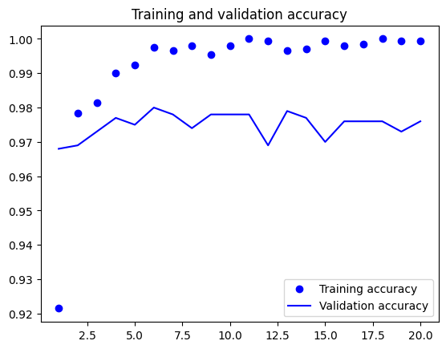

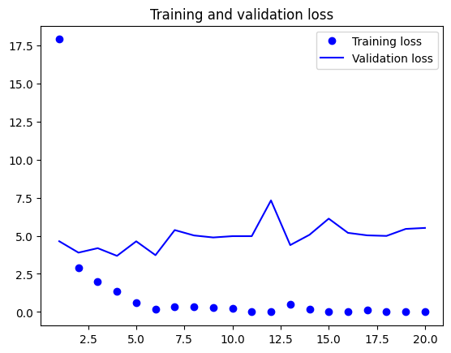

```python
import matplotlib.pyplot as plt
accuracy6 = hist6.history["accuracy"]
valaccuracy6 = hist6.history["val_accuracy"]
los6 = hist6.history["loss"]
vallos6 = hist6.history["val_loss"]
epochs = range(1, len(accuracy6) + 1)
plt.plot(epochs, accuracy6, "bo", label="Training accuracy")
plt.plot(epochs, valaccuracy6, "b", label="Validation accuracy")
plt.title("Training and validation accuracy")
plt.legend()
plt.figure()
plt.plot(epochs, los6, "bo", label="Training loss")
plt.plot(epochs, vallos6, "b", label="Validation loss")
plt.title("Training and validation loss")
plt.legend()
plt.show()
```

VGG16 convolutional base instantiation and freezing

```python
convolution_base  = keras.applications.vgg16.VGG16(
    weights="imagenet",
    include_top=False)
convolution_base.trainable = False

convolution_base.trainable = True
print("This is the number of trainable weights "
      "before freezing the conv base:", len(convolution_base.trainable_weights))

convolution_base.trainable = False
print("This is the number of trainable weights "
      "after freezing the conv base:", len(convolution_base.trainable_weights))
```

```
This is the number of trainable weights before freezing the conv base: 26
This is the number of trainable weights after freezing the conv base: 0
```

Model is now performing with a classifier and agumentation to convulation base

```python
augmentation2 = keras.Sequential(
    [
        layers.RandomFlip("horizontal"),
        layers.RandomRotation(0.1),
        layers.RandomZoom(0.2),
    ]
)

input22 = keras.Input(shape=(180, 180, 3))
x1 = augmentation2(input22)
x1 =keras.layers.Lambda(
     lambda x: keras.applications.vgg16.preprocess_input(x))(x1)
x1 = convolution_base(x1)
x1 = layers.Flatten()(x1)
x1 = layers.Dense(256)(x1)
x1 = layers.Dropout(0.5)(x1)
outputs = layers.Dense(1, activation="sigmoid")(x1)
model = keras.Model(input22, outputs)
model.compile(loss="binary_crossentropy",
              optimizer="rmsprop",
              metrics=["accuracy"])
```

```python
callbacks = [
    keras.callbacks.ModelCheckpoint(
        filepath="features_extraction_with_augmentation2.keras",
        save_best_only=True,
        monitor="val_loss"
    )
]

history = model.fit(
    train,
    epochs=10,
    validation_data=validation,
    callbacks=callbacks
)
```

```
63/63 ━━━━━━━━━━━━━━━━━━━━ 18s 222ms/step - accuracy: 0.8303 - loss: 36.5900 - val_accuracy: 0.9100 - val_loss: 17.0759
63/63 ━━━━━━━━━━━━━━━━━━━━ 16s 204ms/step - accuracy: 0.9268 - loss: 11.8919 - val_accuracy: 0.9820 - val_loss: 1.8894
63/63 ━━━━━━━━━━━━━━━━━━━━ 18s 163ms/step - accuracy: 0.9601 - loss: 5.1224 - val_accuracy: 0.9770 - val_loss: 2.6429
63/63 ━━━━━━━━━━━━━━━━━━━━ 10s 167ms/step - accuracy: 0.9594 - loss: 5.2229 - val_accuracy: 0.9640 - val_loss: 5.5138
63/63 ━━━━━━━━━━━━━━━━━━━━ 10s 167ms/step - accuracy: 0.9607 - loss: 4.8999 - val_accuracy: 0.9570 - val_loss: 6.3393
63/63 ━━━━━━━━━━━━━━━━━━━━ 20s 163ms/step - accuracy: 0.9732 - loss: 4.5346 - val_accuracy: 0.9690 - val_loss: 5.9684
63/63 ━━━━━━━━━━━━━━━━━━━━ 10s 166ms/step - accuracy: 0.9637 - loss: 3.8917 - val_accuracy: 0.9820 - val_loss: 2.9458
63/63 ━━━━━━━━━━━━━━━━━━━━ 20s 165ms/step - accuracy: 0.9808 - loss: 1.3837 - val_accuracy: 0.9780 - val_loss: 3.1161
63/63 ━━━━━━━━━━━━━━━━━━━━ 20s 166ms/step - accuracy: 0.9661 - loss: 4.5307 - val_accuracy: 0.9780 - val_loss: 3.6173
63/63 ━━━━━━━━━━━━━━━━━━━━ 21s 167ms/step - accuracy: 0.9725 - loss: 2.7100 - val_accuracy: 0.9830 - val_loss: 2.2419
```

```python
!ls -lh features_extraction_with_augmentation2.keras
```

```
-rw-r--r-- 1 root root 82M Oct 20 21:25 features_extraction_with_augmentation2.keras
```

```python
from tensorflow import keras
from tensorflow.keras import layers
from tensorflow.keras.applications import vgg16

# Define the model
augmentation2 = keras.Sequential(
    [
        layers.RandomFlip("horizontal"),
        layers.RandomRotation(0.1),
        layers.RandomZoom(0.2),
    ]
)

input22 = keras.Input(shape=(180, 180, 3))

x1 = augmentation2(input22)

# Specify output_shape for Lambda layer
x1 = keras.layers.Lambda(
    lambda x: vgg16.preprocess_input(x),
    output_shape=(180, 180, 3)
)(x1)

x1 = convolution_base(x1)
x1 = layers.Flatten()(x1)
x1 = layers.Dense(256)(x1)
x1 = layers.Dropout(0.5)(x1)
outputs = layers.Dense(1, activation="sigmoid")(x1)

model = keras.Model(input22, outputs)
model.compile(loss="binary_crossentropy",
              optimizer="rmsprop",
              metrics=["accuracy"])

# Save the model
callbacks = [
    keras.callbacks.ModelCheckpoint(
        filepath="features_extraction_with_augmentation2.keras",
        save_best_only=True,
        monitor="val_loss"
    )
]

history = model.fit(
    train,
    epochs=10,
    validation_data=validation,
    callbacks=callbacks
)
```

```
63/63 ━━━━━━━━━━━━━━━━━━━━ 13s 183ms/step - accuracy: 0.8397 - loss: 46.7284 - val_accuracy: 0.9600 - val_loss: 5.9875
63/63 ━━━━━━━━━━━━━━━━━━━━ 20s 175ms/step - accuracy: 0.9568 - loss: 4.7125 - val_accuracy: 0.9770 - val_loss: 3.0804
63/63 ━━━━━━━━━━━━━━━━━━━━ 22s 206ms/step - accuracy: 0.9474 - loss: 7.9517 - val_accuracy: 0.9750 - val_loss: 3.0446
63/63 ━━━━━━━━━━━━━━━━━━━━ 12s 194ms/step - accuracy: 0.9597 - loss: 4.7672 - val_accuracy: 0.9740 - val_loss: 3.6588
63/63 ━━━━━━━━━━━━━━━━━━━━ 19s 173ms/step - accuracy: 0.9727 - loss: 3.6255 - val_accuracy: 0.9780 - val_loss: 2.4029
63/63 ━━━━━━━━━━━━━━━━━━━━ 22s 192ms/step - accuracy: 0.9753 - loss: 2.4946 - val_accuracy: 0.9760 - val_loss: 2.8111
63/63 ━━━━━━━━━━━━━━━━━━━━ 19s 175ms/step - accuracy: 0.9738 - loss: 2.1517 - val_accuracy: 0.9830 - val_loss: 2.1875
63/63 ━━━━━━━━━━━━━━━━━━━━ 20s 167ms/step - accuracy: 0.9690 - loss: 3.6547 - val_accuracy: 0.9810 - val_loss: 3.2773
63/63 ━━━━━━━━━━━━━━━━━━━━ 22s 193ms/step - accuracy: 0.9770 - loss: 1.9963 - val_accuracy: 0.9720 - val_loss: 5.0781
63/63 ━━━━━━━━━━━━━━━━━━━━ 19s 167ms/step - accuracy: 0.9739 - loss: 2.2859 - val_accuracy: 0.9740 - val_loss: 4.6749
```

Fine-tuning a pretrained model

Freezing all layers until the fourth from the last

```python
convolution_base.trainable = True
for layer in convolution_base.layers[:-4]:
    layer.trainable = False
```

```python
model.compile(loss="binary_crossentropy",
              optimizer=keras.optimizers.RMSprop(learning_rate=1e-5),
              metrics=["accuracy"])

callbackstu = [
    keras.callbacks.ModelCheckpoint(
        filepath="fine_tuning.keras",
        save_best_only=True,
        monitor="val_loss")
]
historytune = model.fit(
    train,
    epochs=30,
    validation_data=validation,
    callbacks=callbackstu)
```

```
63/63 ━━━━━━━━━━━━━━━━━━━━ 15s 202ms/step - accuracy: 0.9788 - loss: 2.3027 - val_accuracy: 0.9820 - val_loss: 2.6110
63/63 ━━━━━━━━━━━━━━━━━━━━ 22s 224ms/step - accuracy: 0.9754 - loss: 1.9232 - val_accuracy: 0.9850 - val_loss: 2.1901
63/63 ━━━━━━━━━━━━━━━━━━━━ 20s 219ms/step - accuracy: 0.9828 - loss: 0.7837 - val_accuracy: 0.9810 - val_loss: 2.1486
63/63 ━━━━━━━━━━━━━━━━━━━━ 19s 195ms/step - accuracy: 0.9814 - loss: 1.0268 - val_accuracy: 0.9830 - val_loss: 1.9146
63/63 ━━━━━━━━━━━━━━━━━━━━ 20s 182ms/step - accuracy: 0.9853 - loss: 1.0208 - val_accuracy: 0.9790 - val_loss: 2.1104
63/63 ━━━━━━━━━━━━━━━━━━━━ 12s 186ms/step - accuracy: 0.9851 - loss: 0.5961 - val_accuracy: 0.9780 - val_loss: 2.1193
63/63 ━━━━━━━━━━━━━━━━━━━━ 22s 209ms/step - accuracy: 0.9859 - loss: 0.8508 - val_accuracy: 0.9810 - val_loss: 2.0029
63/63 ━━━━━━━━━━━━━━━━━━━━ 20s 194ms/step - accuracy: 0.9876 - loss: 0.5749 - val_accuracy: 0.9820 - val_loss: 1.9128
63/63 ━━━━━━━━━━━━━━━━━━━━ 12s 198ms/step - accuracy: 0.9850 - loss: 0.5999 - val_accuracy: 0.9840 - val_loss: 1.8220
63/63 ━━━━━━━━━━━━━━━━━━━━ 20s 195ms/step - accuracy: 0.9918 - loss: 0.2843 - val_accuracy: 0.9830 - val_loss: 1.5469
63/63 ━━━━━━━━━━━━━━━━━━━━ 20s 195ms/step - accuracy: 0.9908 - loss: 0.2572 - val_accuracy: 0.9840 - val_loss: 1.5041
63/63 ━━━━━━━━━━━━━━━━━━━━ 20s 184ms/step - accuracy: 0.9961 - loss: 0.1606 - val_accuracy: 0.9820 - val_loss: 2.1041
63/63 ━━━━━━━━━━━━━━━━━━━━ 20s 183ms/step - accuracy: 0.9866 - loss: 0.5019 - val_accuracy: 0.9790 - val_loss: 2.0995
63/63 ━━━━━━━━━━━━━━━━━━━━ 21s 185ms/step - accuracy: 0.9912 - loss: 0.2824 - val_accuracy: 0.9870 - val_loss: 1.5510
63/63 ━━━━━━━━━━━━━━━━━━━━ 16s 253ms/step - accuracy: 0.9934 - loss: 0.3382 - val_accuracy: 0.9850 - val_loss: 1.4624
63/63 ━━━━━━━━━━━━━━━━━━━━ 18s 209ms/step - accuracy: 0.9953 - loss: 0.1869 - val_accuracy: 0.9820 - val_loss: 1.6892
63/63 ━━━━━━━━━━━━━━━━━━━━ 12s 184ms/step - accuracy: 0.9900 - loss: 0.2587 - val_accuracy: 0.9740 - val_loss: 1.9642
63/63 ━━━━━━━━━━━━━━━━━━━━ 22s 208ms/step - accuracy: 0.9905 - loss: 0.4821 - val_accuracy: 0.9820 - val_loss: 1.5364
63/63 ━━━━━━━━━━━━━━━━━━━━ 19s 186ms/step - accuracy: 0.9925 - loss: 0.4019 - val_accuracy: 0.9830 - val_loss: 1.5864
63/63 ━━━━━━━━━━━━━━━━━━━━ 12s 187ms/step - accuracy: 0.9936 - loss: 0.2004 - val_accuracy: 0.9850 - val_loss: 1.6283
63/63 ━━━━━━━━━━━━━━━━━━━━ 22s 211ms/step - accuracy: 0.9950 - loss: 0.1810 - val_accuracy: 0.9850 - val_loss: 1.7419
63/63 ━━━━━━━━━━━━━━━━━━━━ 20s 208ms/step - accuracy: 0.9919 - loss: 0.3344 - val_accuracy: 0.9850 - val_loss: 1.5372
63/63 ━━━━━━━━━━━━━━━━━━━━ 17s 276ms/step - accuracy: 0.9976 - loss: 0.0676 - val_accuracy: 0.9840 - val_loss: 1.3909
63/63 ━━━━━━━━━━━━━━━━━━━━ 15s 195ms/step - accuracy: 0.9956 - loss: 0.1009 - val_accuracy: 0.9870 - val_loss: 1.3418
63/63 ━━━━━━━━━━━━━━━━━━━━ 21s 209ms/step - accuracy: 0.9956 - loss: 0.1562 - val_accuracy: 0.9870 - val_loss: 1.4551
63/63 ━━━━━━━━━━━━━━━━━━━━ 19s 184ms/step - accuracy: 0.9977 - loss: 0.0464 - val_accuracy: 0.9870 - val_loss: 1.4467
63/63 ━━━━━━━━━━━━━━━━━━━━ 12s 184ms/step - accuracy: 0.9925 - loss: 0.2680 - val_accuracy: 0.9850 - val_loss: 1.5596
63/63 ━━━━━━━━━━━━━━━━━━━━ 12s 183ms/step - accuracy: 0.9941 - loss: 0.1691 - val_accuracy: 0.9860 - val_loss: 1.4196
63/63 ━━━━━━━━━━━━━━━━━━━━ 20s 181ms/step - accuracy: 0.9932 - loss: 0.1149 - val_accuracy: 0.9800 - val_loss: 1.4791
63/63 ━━━━━━━━━━━━━━━━━━━━ 13s 208ms/step - accuracy: 0.9970 - loss: 0.0592 - val_accuracy: 0.9870 - val_loss: 1.3746
```

```python
model_tuning = keras.models.load_model("fine_tuning.keras",safe_mode=False)
test_loss, test_acc = model.evaluate(test)
print(f"Test accuracy: {test_acc:.3f}")
```

```
32/32 ━━━━━━━━━━━━━━━━━━━━ 3s 106ms/step - accuracy: 0.9791 - loss: 1.6499
Test accuracy: 0.974
```